# Análisis exploratorio de datos con `tidyverse`

Parte 1: Fundamentos de análisis exploratorio en `R`

Autores

Rodrigo Zepeda-Tello

Última actualización

October 11, 2022

Resumen

Mostramos cómo funciona `dplyr` para filtrar (`filter`), seleccionar (`select`), mutar (`mutate`), agrupar (`group_by`), y resumir (`summarise`) bases de datos en `R`

**Note**

Los datos están disponibles en el [Github](https://github.com/RodrigoZepeda/CursoR/tree/master/datasets) y en [Dropbox](https://www.dropbox.com/sh/ajgteruqo1wf47d/AADMfTnIUeIFSn_3whMVYgjfa?dl=0)

**Warning**

Si aún no cuentas con una instalación de `tidyverse` dentro de `R` corre la siguiente instrucción:

```r
install.packages("tidyverse")
```

## 1 El flujo de trabajo de trabajo con datos

En general el flujo de trabajo de un análisis de datos se divide en tres componentes principales:

1. **Preparación de los datos** lo que incluye la recolección (no discutida aquí), la **importación** de los datos y la **limpieza** inicial (por ejemplo el poner nombres a las columnas u homologar mayúsculas y minúsculas) para generar una base de trabajo.

**Warning**

Una vez recolectados la recomendación es que las bases de datos **no se toquen** una vez se tiene la información. Entre menos modifiquemos la base de datos hay menor probabilidad de cometer errores y accidentes que resulten en **pérdida de información**.

2. **Análisis de datos** incluye tres pasos que fluyen en cualquier orden:
1. **Formulación de preguntas** ¿qué me gustaría saber de mis datos?_
2. **Visualización de los datos** ¿puede una gráfica ayudarme a responder mi pregunta u orientarme hacia qué analizar?
3. **Análisis de los datos:** ¿qué resumen de la información (por ejemplo una tabla o un promedio) resulta eficaz para presentar lo que me interesa?
3. Una vez se tienen los datos analizados continuamos a la parte de **comunicación** donde buscamos **generar tablas, gráficas y reportes** (entre otros) que comuniquen nuestros datos al público.

El siguiente diagrama (traducido de [aquí](https://emanuelaf.github.io/data-an-workflow.html)) intenta resumir el flujo de trabajo:

```
flowchart TB;

    subgraph C[Comunicación]
       Tablas --> Reportes
       G[Gráficas] --> Reportes
    end

    subgraph AD[Análisis de datos]
        FP[Preguntas]  --> V[Visualización]
        V  --> FP
        V  --> AN[Análisis]
        AN --> FP
        AN --> V
        FP --> AN
    end

    subgraph PD[Preparación de los datos]
        R[Recolección] --> I[Importación]
        I  --> L[Limpieza]
    end

    PD --> AD --> C
```

## 2 Armado de un proyecto

En `RStudio` para un proyecto de análisis de datos la recomendación es crear un `Project`. Ésta es una carpeta especial en la cual se almacena todo el código, las bases de datos e incluso los registros de las versiones de los paquetes que estás usando Con pasarle a otra persona tu proyecto (`Project`) ésta podrá reproducir absolutamente todo sin preocuparse por tener que acomodar las rutas a los archivos o instalar los paquetes que tú usaste.

Para armar un proyecto puedes ir a `File > New Project`. Esto abrirá una ventana como sigue:

[figure not shown]

Opciones de proyecto incluyen nuevo directorio o existente así como control de versiones

Existen diferentes opciones: empezar a crear un proyecto desde cero (`New Directory`) o bien trabajar con algún folder que ya tenemos `Existing directory`. El control de versiones (`Version Control`) es una herramienta más avanzada de programación y no la discutiremos por ahora.

Elige la opción de `New Directory` y en la ventana que sigue elige `New R Proyect`. Notarás que esto sirve para muchas cosas entre ellas armar presentaciones y páginas web. Por ahora trabajaremos sólo con código normal.

[figure not shown]

Las opciones de tipo de proyecto incluyen blogs, páginas web y libros. Por ahora comenzamos con `New Proyect` para hacer un proyecto nuevo sin opciones específicas de los otros tipos.

Finalmente en la tercer ventana elegimos el nombre del proyecto, el folder dentro de nuestros documentos donde habrá de guardarse y activamos las opciones:

- `renv` sirve para controlar los paquetes de `R` usados. Si eliges la opción `renv`, cualquier otra persona que use el proyecto se le instalarán los paquetes que tú usaste y las versiones específicas (digamos tu `ggplot2` es del 2021 entonces esa persona tendrá ese `ggplot2` cuando abra el proyecto).
- `git` sirve para guardar un historial de tu código. Explicaremos más adelante su funcionamiento principal pero la idea es que se guarde cada cambio que haces en el código (pues `ctrl Z` es limitado).
- `Open in new session` cierra la ventana actual de `RStudio` y te abre el proyecto en un nuevo lienzo en blanco para que comiences tu trabajo.

[figure not shown]

Un nuevo proyecto con nombre `AnalisisDatos`, en mi carpeta de `Dropbox` con las opciones de `git` y `renv` habilitadas. Se solicitó a `R` además abrir en una sesión nueva.

Una vez iniciado el proyecto nos aparecerá un mensaje similar a este en una nueva consola de `R``:

```bash
The version of R recorded in the lockfile will be updated:
- R      [*] -> [4.2.1]

* Lockfile written to '~/AnalisisDatos/renv.lock'.
```

¡Podemos empezar a usarlo!

**Warning**

Todas las bases de datos que utilicemos dentro de estas notas supondremos están almacenadas dentro del proyecto `AnalisisDatos` el cual está en tus documentos donde sea hayas elegido.

> Por favor copia todos los datos que uses **dentro del proyecto** para que así, a cualquier persona que le envíes el proyecto pueda usarlo.

## 3 Lectura de bases de datos

`R` sirve para abrir cualquier tipo de dato. En particular es posible leer bases de datos desde `Excel`, `csv`, `txt`, `Stata`. También (aunque no lo veremos) puede leer imágenes, videos, datos provenientes de documentos `pdf`, páginas web, mapas, etc. Al día de hoy no he encontrado un sólo tipo de dato que no pueda leer `R`.

Las bases de datos si ya están recolectadas **no se tocan**. Lo que haremos en `R` será leerlas, copiarlas en una base nueva y trabajar sobre la base nueva sin modificar la original. De esta forma, cualquier error que cometamos ¡y seguro cometeremos muchos! no afectará la original. Esto permite además tener un flujo de trabajo seguro (en el sentido de que estamos seguros que no borraremos nada).

### 3.1 Lectura de datos desde un archivo delimitado (`csv` ó `txt`).

Los documentos de datos, si son (relativamente) medianas, pueden ser compartidos en archivos de texto que se pueden abrir con el bloc de notas. Por ejemplo, el documento `casos_covid_agosto_2022.csv` se ve como sigue:

```
"FECHA_SINTOMAS","n"
"2020-01-01","287"
"2020-01-02","233"
"2020-01-03","247"
"2020-01-04","245"
```

por otro lado el documento `embarazo_adolescente.txt` es un archivo delimitado por tabs (a veces llamados `tsv`) donde cada columna ocurre después de un `tab` (espacio largo):

```
Location    PovPct  Brth15to17  Brth18to19  ViolCrime   TeenBrth
Alabama 20.1    31.5    88.7    11.2    54.5
Alaska  7.1 18.9    73.7    9.1 39.5
Arizona 16.1    35  102.5   10.4    61.2
Arkansas    14.9    31.6    101.7   10.4    59.9
```

finalmente, `covid_sinave_bc_bcs.txt` es un archivo donde las columnas son separadas por `|`:

```
SECTOR|ENTIDAD_UM|SEXO|ENTIDAD_NAC|ENTIDAD_RES|TIPO_PACIENTE|FECHA_INGRESO|FECHA_SINTOMAS|FECHA_DEF|EDAD|HABLA_LENGUA_INDIG|DIABETES|TOMA_MUESTRA_LAB|RESULTADO_LAB|TOMA_MUESTRA_ANTIGENO|RESULTADO_ANTIGENO|CLASIFICACION_FINAL|UCI
4|03|2|12|03|1|2021-07-05T00:00:00Z|2021-07-04T00:00:00Z|NA|22|2|2|2|97|1|1|3|97
4|03|2|03|03|1|2021-07-12T00:00:00Z|2021-07-11T00:00:00Z|NA|52|2|1|2|97|1|2|7|97
4|03|2|03|03|1|2021-07-22T00:00:00Z|2021-07-19T00:00:00Z|NA|19|2|2|2|97|1|2|7|97
12|03|1|03|03|1|2021-07-15T00:00:00Z|2021-07-13T00:00:00Z|NA|10|2|2|2|97|1|1|3|97
```

Todos estos archivos son archivos de texto simple delimitados y se pueden leer con la librería `readr`.

#### Lectura simple

Para leer los archivos basta con `File > Import dataset` o bien con código:

```r
casos_covid <- read_csv("casos_covid_agosto_2022.csv")
```

Para los archivos delimitados por espacios podemos usar `read_tsv`:

```r
adolescentes <- read_tsv("embarazo_adolescente.txt")
```

Finalmente archivos con delimitadores que no son comas ni tabs (como los `|` ) puedes usar `read_delim` y especificar el separador `delim`:

```r
covid <- read_delim("covid_sinave_bc_bcs.txt", delim = "|")
```

#### Complicaciones

La base de datos `zapopan.csv` contiene las estimaciones de la población del municipio homónimo por parte del INEGI. Sin embargo, al momento de leerla pasan dos cosas:

1. Los acentos en algunos equipos no se leen bien
2. La primera fila no representa nada pues sólo dice **Datos**.

Aquí una muestra de cómo viene el archivo. Nota que en mi equipo los acentos y las ñ aparecen como el símbolo `?`:

Datos Poblacionales,,,,,,,,,,, Unidad,Nombre Unidad,Zona Coplademun,Habitantes,Hombres,Mujeres,Poblacin de 0 a 14 Aos,Poblacin de 15 a 64 Aos,Poblacin Mayor de 18 Aos,Viviendas Habitadas,Promedio de Ocupantes por Vivienda,Clave INEGI 1,12 de diciembre,7,“1,782”,“1,005”,953,759,“1,143”,“1,012”,394,5.221,0 2,27 de Septiembre,1B,“1,730”,824,906,469,“1,122”,“1,171”,478,4.141666667,001-F 3,“Abetos, Los”,1B,367,179,188,121,240,231,101,3.63,002-L

Para leer esta base es necesario saltarnos la primera fila pues **Datos Poblacionales** no es un nombre de columna. Para ello usamos `skip = 1` indicándole que se salte (`skip`) una fila (`= 1`). Por otro lado para los acentos usamos el encoding de `WINDOWS-1252`. Los más comunes para acentos en México son `UTF-8` y `WINDOWS-1252`. Cuando no leemos bien los acentos vale la pena probar ambos para hallar el correcto:

```r
zapopan <- read_csv("zapopan.csv",
                    locale = locale(encoding = "WINDOWS-1252"),
                    skip = 1)
```

### 3.2 Lectura de datos desde un `Excel`

#### Lectura simple

Para leer datos desde un Excel podemos usar la `Import From > Excel` o bien `read_excel` dentro de la librería `readxl`:

```r
library(readxl)
```

dado un archivo como `persona_cigarros.xlsx` podemos leerlo directamente:

```r
cigarros <- read_excel("persona_cigarros.xlsx")
```

#### Complicaciones

Algunos archivos como `Poblacion_01.xlsx` contienen filas tanto al inicio como al final que funcionan como descriptores del archivo. Al momento de leerlo debemos ignorar estas partes:

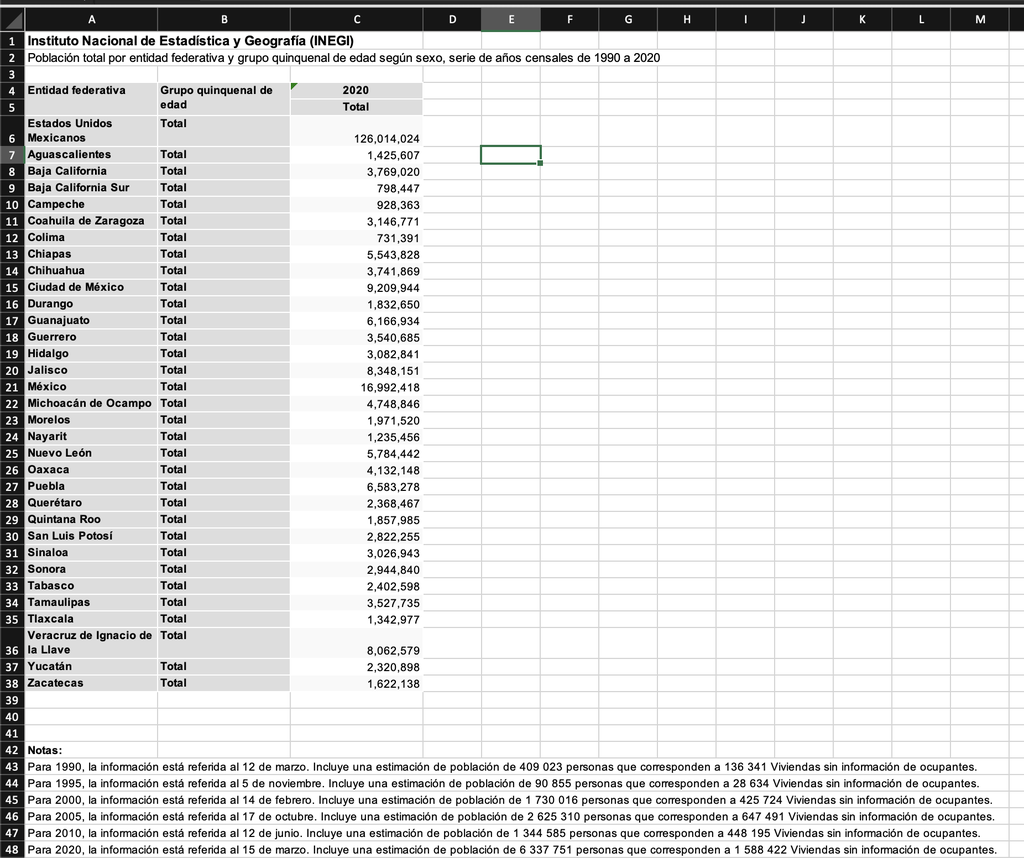

Para ello en `read_excel` podemos especificar el rango de las celdas que nos interesa exportar indicando las dos esquinas del rectángulo de celdas:

```r
poblacion <- read_excel("Poblacion_01.xlsx", range = "A5:C38")
```

### 3.3 Ejercicios

1. Lee las bases de datos `ile-2019-2021.csv`, `IME_2020.xls` y `niños.txt`.

## 4 Análisis de bases de datos

Vamos a leer la base de datos `conjunto_de_datos_defunciones_generales_2017.csv` la cual contiene el registro de mortalidad en México para el año `2017` del INEGI:

```r
mortalidad_2017 <- read_csv("conjunto_de_datos_defunciones_generales_2017.csv")
```

Aquí sólo muestro las filas de la base:

| ent_regis | mun_regis | ent_resid | mun_resid | tloc_resid | loc_resid | ent_ocurr | mun_ocurr | tloc_ocurr | loc_ocurr | causa_def | lista_mex | sexo | edad | dia_ocurr | mes_ocurr | anio_ocur | dia_regis | mes_regis | anio_regis | dia_nacim | mes_nacim | anio_nacim | ocupacion | escolarida | edo_civil | presunto | ocurr_trab | lugar_ocur | necropsia | … |
| --- | --- | --- | --- | --- | --- | --- | --- | --- | --- | --- | --- | --- | --- | --- | --- | --- | --- | --- | --- | --- | --- | --- | --- | --- | --- | --- | --- | --- | --- | --- |
| 01 | 001 | 01 | 001 | 15 | 0001 | 01 | 001 | 15 | 0001 | I679 | 30Z | 2 | 4068 | 26 | 7 | 1994 | 19 | 1 | 2017 | 99 | 99 | 1926 | 11 | 3 | 3 | 8 | 8 | 88 | 9 | … |
| 01 | 009 | 01 | 009 | 1 | 0016 | 01 | 009 | 1 | 0016 | I64X | 30D | 2 | 4090 | 10 | 11 | 2011 | 30 | 1 | 2017 | 31 | 10 | 1921 | 11 | 3 | 5 | 8 | 8 | 88 | 2 | … |
| 01 | 001 | 01 | 001 | 15 | 0001 | 01 | 001 | 15 | 0001 | E112 | 20D | 1 | 4088 | 12 | 2 | 2011 | 99 | 1 | 2017 | 19 | 11 | 1922 | 4 | 3 | 3 | 8 | 8 | 88 | 2 | … |
| 01 | 006 | 01 | 006 | 8 | 0001 | 01 | 006 | 8 | 0001 | X590 | 51Z | 2 | 4096 | 27 | 12 | 2016 | 10 | 1 | 2017 | 20 | 1 | 1920 | 11 | 3 | 3 | 1 | 9 | 9 | 9 | … |
| 01 | 001 | 01 | 001 | 15 | 0001 | 01 | 001 | 15 | 0001 | I251 | 28Z | 2 | 4051 | 1 | 3 | 2016 | 13 | 1 | 2017 | 11 | 11 | 1964 | 9 | 1 | 2 | 8 | 8 | 88 | 2 | … |
| 01 | 001 | 01 | 001 | 15 | 0001 | 01 | 001 | 15 | 0001 | N009 | 38A | 1 | 4078 | 1 | 7 | 2016 | 10 | 1 | 2017 | 8 | 5 | 1938 | 11 | 3 | 5 | 8 | 8 | 88 | 2 | … |

La función `glimpse` nos permite darnos una idea de la composición de nuestros datos:

```r
mortalidad_2017 %>% glimpse()
```

```
Rows: 703,047
Columns: 59
$ ent_regis  <chr> "01", "01", "01", "01", "01", "01", "01", "01", "01", "01",…
$ mun_regis  <chr> "001", "009", "001", "006", "001", "001", "001", "001", "00…
$ ent_resid  <chr> "01", "01", "01", "01", "01", "01", "01", "01", "01", "01",…
$ mun_resid  <chr> "001", "009", "001", "006", "001", "001", "001", "001", "00…
$ tloc_resid <dbl> 15, 1, 15, 8, 15, 15, 15, 15, 15, 5, 15, 1, 15, 15, 1, 15, …
$ loc_resid  <chr> "0001", "0016", "0001", "0001", "0001", "0001", "0001", "00…
$ ent_ocurr  <chr> "01", "01", "01", "01", "01", "01", "01", "01", "01", "01",…
$ mun_ocurr  <chr> "001", "009", "001", "006", "001", "001", "001", "001", "00…
$ tloc_ocurr <dbl> 15, 1, 15, 8, 15, 15, 15, 15, 15, 15, 15, 15, 15, 15, 15, 1…
$ loc_ocurr  <chr> "0001", "0016", "0001", "0001", "0001", "0001", "0001", "00…
$ causa_def  <chr> "I679", "I64X", "E112", "X590", "I251", "N009", "E129", "M6…
$ lista_mex  <chr> "30Z", "30D", "20D", "51Z", "28Z", "38A", "20D", "37H", "09…
$ sexo       <dbl> 2, 2, 1, 2, 2, 1, 1, 2, 2, 1, 1, 1, 2, 1, 1, 2, 1, 1, 2, 1,…
```

[output cut: 46 more lines]

Hacer esto es lo mismo que hacerlo con el pipe nativo de `R`, `|>`:

```r
mortalidad_2017 |> glimpse()
```

o bien ponerlo dentro del `glimpse`:

```r
glimpse(mortalidad_2017)
```

El comando `ncol` nos muestra el número de columnas en la base de datos y `tally` nos cuenta el número de filas en la base de datos.

```r
mortalidad_2017 %>% ncol() #Columnas
```

```
[1] 59
```

```r
mortalidad_2017 %>% tally() #Filas
```

```
# A tibble: 1 × 1
       n
   <int>
1 703047
```

El comando `nrow` hace lo mismo: conteo de filas. Pero no es tan recomendado como veremos más adelante.

```r
mortalidad_2017 %>% nrow() #Filas
```

```
[1] 703047
```

Podemos ver los nombres de las columnas de la base de datos con `colnames`:

```r
#Mostramos las columnas
mortalidad_2017 %>% colnames()
```

```
 [1] "ent_regis"  "mun_regis"  "ent_resid"  "mun_resid"  "tloc_resid"
 [6] "loc_resid"  "ent_ocurr"  "mun_ocurr"  "tloc_ocurr" "loc_ocurr"
[11] "causa_def"  "lista_mex"  "sexo"       "edad"       "dia_ocurr"
[16] "mes_ocurr"  "anio_ocur"  "dia_regis"  "mes_regis"  "anio_regis"
[21] "dia_nacim"  "mes_nacim"  "anio_nacim" "ocupacion"  "escolarida"
[26] "edo_civil"  "presunto"   "ocurr_trab" "lugar_ocur" "necropsia"
[31] "asist_medi" "sitio_ocur" "cond_cert"  "nacionalid" "derechohab"
[36] "embarazo"   "rel_emba"   "horas"      "minutos"    "capitulo"
[41] "grupo"      "lista1"     "gr_lismex"  "vio_fami"   "area_ur"
[46] "edad_agru"  "complicaro" "dia_cert"   "mes_cert"   "anio_cert"
[51] "maternas"   "lengua"     "cond_act"   "par_agre"   "ent_ocules"
[56] "mun_ocules" "loc_ocules" "razon_m"    "dis_re_oax"
```

Una descripción de las variables las puedes encontrar en el archivo `diccionario_datos_defunciones_generales_2017.csv`. Donde aparece como sigue:

| NOMBRE_CAMPO | LONGITUD | TIPO | NEMÓNICO | CATÁLOGO | RANGO_CLAVES |
| --- | --- | --- | --- | --- | --- |
| Entidad Registro | 2 | N | ent_regis | decateml | 01-32 |
| Municipio Registro | 3 | N | mun_regis | decateml | 001-570 |
| Entidad Residencia | 2 | N | ent_resid | decateml | 01-35, 99 |
| Municipio Residencia | 3 | N | mun_resid | decateml | 001-570, 999 |
| Tamaño Localidad Residencia | 2 | N | tloc_resid | detamloc | 01-17,99 |
| Clave Localidad de Residencia | 4 | N | loc_resid | decateml | 0001 - 6999, 9999 |
| Entidad Ocurrencia | 2 | N | ent_ocurr | decateml | 01-35,99 |
| Municipio Ocurrencia | 3 | N | mun_ocurr | decateml | 001-570,999 |
| Tamaño de Localidad Ocurrencia | 2 | N | tloc_ocurr | detamloc | 01-17,99 |
| Clave Localidad de Ocurrencia | 4 | N | loc_ocur | decateml | 0001 - 6999, 9999 |
| Causa Defunción (Lista Detallada) | 4 | A | causa_def | decatcausa | NA |
| Causa Defunción (Lista Mexicana) | 3 | A | lista_mex | delistamex | NA |
| Sexo | 1 | N | sexo | desexo | 1-2,9 |
| Edad | 4 | N | edad | deedad | 1001-1023, 1097,1098, 2001-2029,2098, 3001-3011,3098, 4001-4120, 4998 |
| Día Defunción | 2 | N | dia_ocurr | dedias | 01-31,99 |
| Mes Defunción | 2 | N | mes_ocurr | demeses | 01-12, 99 |
| Año Defunción | 4 | N | anio_ocur | deaño | 1900-Año estadística, 9999 |
| Día Registro | 2 | N | dia_regis | dedias | 01-31,99 |
| Mes Registro | 2 | N | mes_regis | demeses | 01-12 |
| Año Registro | 4 | N | anio_regis | deaño | Año estadística |
| Día Nacimiento | 2 | N | dia_nacim | dedias | 01-31,99 |
| Mes Nacimiento | 2 | N | mes_nacim | demeses | 01-12,99 |
| Año Nacimiento | 4 | N | anio_nacim | deaño | 1900-Año estadística, 9999 |
| Ocupación | 2 | N | ocupacion | deocupa | 1 - 11, 97, 98, 99 |
| Escolaridad | 2 | N | escolarida | deesco | 1-10, 88, 99 |
| Estado Conyugal | 1 | N | edo_civil | deedocony | 1-6, 8, 9 |
| Presunto | 1 | N | presunto | depresunto | 1-5, 8 |
| Ocurrió Trabajo | 1 | N | ocurr_trab | deocutrab | 1-2, 8, 9 |
| Sitio donde Ocurrio la Lesión | 2 | N | lugar_ocur | desitiolesion | 0 - 9, 88 |
| Necropsia | 1 | N | necropsia | denecrop | 1-2, 9 |
| Asistencia Médica | 1 | N | asist_medi | deasismed | 1-2,9 |
| Sitio donde Ocurrio la Defunción | 2 | N | sitio_ocur | desitiodefun | 1-12,99 |
| Certificada Por | 1 | N | cond_cert | deccertif | 1-5, 8, 9 |
| Nacionalidad | 1 | N | nacionalid | denacion | 1-2, 9 |
| Derechohabiencia | 2 | N | derechohab | dederech | 1-9, 99 |
| Condición de embarazo | 1 | N | embarazo | decondemba | 1-6, 8, 9 |
| Causas relacionadas con embarazo | 1 | N | rel_emba | derelemba | 1,2, 8, 9 |
| Hora de la defunción | 2 | N | horas | dehoradef | 00-23, 99 |
| Minuto de la defunción | 2 | N | minutos | demindef | 00-59, 99 |
| Capitulo | 2 | N | capitulo | decapgpo | NA |
| Grupo | 2 | N | grupo | decapgpo | NA |
| Lista1 | 3 | A | lista1 | delista1 | NA |
| Grupos lista mexicana | 3 | A | gr_lismex | degpolisme | NA |
| Violencia Familiar | 1 | N | vio_fami | deviofam | 1, 2, 8, 9 |
| Area Urbano Rural | 1 | N | area_ur | deurbrur | 1, 2, 9 |
| Edad agrupada | 2 | C | edad_agru | deedadagrup | 01-30 |
| Complicaron el embarazo | 1 | N | complicaro | decomplicaemba | 1, 2, 8, 9 |
| Día de Certificación | 2 | N | dia_cert | dedias | 01-31,99 |
| Mes de Certificación | 2 | N | mes_cert | demeses | 01-12, 99 |
| Año de Certificación | 4 | N | anio_cert | deaño | AE* -1, AE*, 9999 |
| Maternas | 4 | C | maternas | decatcausa | NA |
| Lengua indígena | 1 | N | lengua | delengindi | 1, 2, 8, 9 |
| Condición de Actividad económica | 1 | N | cond_act | decondact | 1, 2, 8, 9 |
| Parentesco del presunto agresor | 2 | N | par_agre | deparenagresor | 1 - 72, 88, 99 |
| Entidad Ocurrencia de la lesión | 2 | N | ent_ocules | decateml | 01-35,88, 99 |
| Municipio Ocurrencia de la lesión | 3 | N | mun_ocules | decateml | 001-570, 888, 999 |
| Clave Localidad de Ocurrencia de la lesión | 4 | N | loc_ocules | decateml | 0001 - 6999, 8888 9999 |
| Razón Materna | 1 | N | razon_m | derazonm | 1 |
| Distritos de Oaxaca | 3 | N | dis_re_oax | decateml | 901-930, 999 |

Una vez tenemos una base de datos podemos analizar sus entradas usando el nombre de la base y corchetes. Por ejemplo:

```r
#Obtengo todo el registro de la columna sexo
mortalidad_2017[ ,"sexo"]
```

```
# A tibble: 6 × 1
   sexo
  <dbl>
1     2
2     2
3     1
4     2
5     2
6     1
```

También podemos usar el número de columna:

```r
#Me regresa las observaciones de la columna 2
#dada por mun_regis
#| eval: false
mortalidad_2017[ ,2]
```

```
# A tibble: 703,047 × 1
   mun_regis
   <chr>
 1 001
 2 009
 3 001
 4 006
 5 001
 6 001
 7 001
 8 001
 9 001
10 001
# … with 703,037 more rows
```

```r
#Me regresa las observaciones de la columna 2
#dada por mun_regis
head(mortalidad_2017[ , 2])
```

También podemos acceder a la base por renglones. Por ejemplo, así vemos el tercer renglón:

```r
mortalidad_2017[3, ]
```

```
# A tibble: 1 × 6
  ent_regis mun_regis ent_resid mun_resid tloc_resid loc_resid
  <chr>     <chr>     <chr>     <chr>          <dbl> <chr>
1 01        001       01        001               15 0001
```

Finalmente, podemos combinar la primer entrada de la columna `lista1` se vería así:

```r
mortalidad_2017[1, "lista1"]
```

```
# A tibble: 1 × 1
  lista1
  <chr>
1 069
```

En resumen, la notación siempre es de la siguiente forma:

$$\text{datos}[\underbrace{f}_{fila},\overbrace{c}^{columna}]$$
Esta notación `notación matricial` es estándar en el mundo de computación y de las matemáticas. Siempre siempre primero es fila luego columna.

Otra forma de seleccionar una columna es con $ seguido del nombre de la columna. Por ejemplo:

```r
mortalidad_2017$edo_civil
```

```
[1] 3 5 3 3 2 5
```

Por ciertos errores en los que se pueden incurrir al crear funciones, se recomienda que se utilice siempre la notación de doble corchete y se evite el signo de $. Pero ambos métodos funcionan. Sólo recuerda que la notación es así:

$$\text{datos}\$\text{Columna}[\underbrace{f}_{\text{Fila}}]$$
Una última opción es con `select`:

```r
mortalidad_2017 %>% select(edo_civil)
```

```
# A tibble: 6 × 1
  edo_civil
      <dbl>
1         3
2         5
3         3
4         3
5         2
6         5
```

la cual nos regresa la columna de estado civil. El comando [`select`](https://dplyr.tidyverse.org/reference/select.html) es bastante útil si, por ejemplo, no recordamos exactamente el nombre de la columna. Por ejemplo, si sólo recordamos que tiene la palabra `"civil"` pero no exactamente cómo se escribe podemos usar `contains`:

```r
#Podemos usar contains si recordamos que dice civil
#pero no el nombre completo
mortalidad_2017 %>% select(contains("civil"))
```

```
# A tibble: 703,047 × 1
   edo_civil
       <dbl>
 1         3
 2         5
 3         3
 4         3
 5         2
 6         5
 7         5
 8         5
 9         5
10         5
# … with 703,037 more rows
```

Podemos preguntarnos, de igual manera por la 7a entrada de `edo_civil` haciendo:

```r
mortalidad_2017$edo_civil[7]
```

```
[1] 5
```

Lo cual es similar (mas no equivalente) a la forma anterior:

```r
mortalidad_2017[7, "edo_civil"]
```

```
# A tibble: 1 × 1
  edo_civil
      <dbl>
1         5
```

En el caso del `tidyverse` el equivalente a `select`, para elegir fila, el equivalente se conoce como `slice`:

```r
#Selecciona la fila 11
mortalidad_2017 %>% slice(11)
```

```
# A tibble: 1 × 59
  ent_regis mun_regis ent_resid mun_re…¹ tloc_…² loc_r…³ ent_o…⁴ mun_o…⁵ tloc_…⁶
  <chr>     <chr>     <chr>     <chr>      <dbl> <chr>   <chr>   <chr>     <dbl>
1 01        001       01        001           15 0001    01      001          15
# … with 50 more variables: loc_ocurr <chr>, causa_def <chr>, lista_mex <chr>,
#   sexo <dbl>, edad <dbl>, dia_ocurr <dbl>, mes_ocurr <dbl>, anio_ocur <dbl>,
#   dia_regis <dbl>, mes_regis <dbl>, anio_regis <dbl>, dia_nacim <dbl>,
#   mes_nacim <dbl>, anio_nacim <dbl>, ocupacion <dbl>, escolarida <dbl>,
#   edo_civil <dbl>, presunto <dbl>, ocurr_trab <dbl>, lugar_ocur <dbl>,
#   necropsia <dbl>, asist_medi <dbl>, sitio_ocur <dbl>, cond_cert <dbl>,
#   nacionalid <dbl>, derechohab <dbl>, embarazo <dbl>, rel_emba <dbl>, …
```

Podemos combinar múltiples argumentos con `%>%`[^1]:

<sup>1</sup> En el mismo renglón debe estar el `%>%` que el último comando para no generar error

```r
mortalidad_2017 %>%
  select(sexo, edo_civil) %>%  #Selecciona edo civil y sexo
  slice(11:20) #Selecciona filas 11 a 20
```

```
# A tibble: 10 × 2
    sexo edo_civil
   <dbl>     <dbl>
 1     1         5
 2     1         5
 3     2         3
 4     1         5
 5     1         5
 6     2         2
 7     1         5
 8     1         5
 9     2         9
10     1         5
```

Esta forma de combinación con `pipes` (`%>%` ó `|>`) será bastante útil más adelante.

Para seleccionar múltiples filas o columnas, como vimos en el ejemplo anterior, hay que crear un vector usando `c`[^2]. Un vector es una lista ordenada de variables del mismo tipo. Por ejemplo:

<sup>2</sup> Se llama `c` por `concatenate` (concatenar).

```r
mi_vector <- c(1, 141, 12)
```

Es un vector de 3 entradas. De hecho, la forma de acceder a sus entradas es la misma que la de los `tibbles` con un agregado: ¡sólo hay filas, no hay columnas!

**Note**

Intuitivamente podemos pensar un vector como una columna de una base de datos. En ella todas las variables son del mismo tipo.

Para acceder a las entradas de un vector es de la siguiente forma:

```r
#Para un vector sólo pongo el número de entrada ¡no hay columna!
mi_vector[2] #entrada 2
```

```
[1] 141
```

En general la notación es la siguiente:

$$\text{vector}[\underbrace{i}_{\text{Entrada}}]$$

```r
#Regresa el nombre de la 5a columna
colnames(mortalidad_2017)[5]
```

```
[1] "tloc_resid"
```

La pregunta también puede hacerse al revés: podemos pedirle a `R` que nos conteste cuál es el número de columna para una columna dada. Por ejemplo, ¿cuál es el número de columna para `edad`?

```r
#Preguntamos a R cuál de las columnas se llama edad
which(colnames(mortalidad_2017) == "edad")
```

```
[1] 14
```

Nota que si preguntamos por una columna que no existe, `R` nos regresa lo siguiente:

```r
#Preguntamos a R cuál de las columnas se llama edad
which(colnames(mortalidad_2017) == "Paraguas")
```

```
integer(0)
```

Esto significa que no hay ninguna columna con ese nombre. Finalmente, nota que el `which` puede regresar múltiples resultados si las cosas se repiten. Por ejemplo, el siguiente comando nos regresa las múltiples entradas del vector `nombres_de_amigos` donde hay un amigo que tiene el nombre de `Alejandro`:

```r
#Creo un vector con nombres de mis amigos
nombres_de_amigos <- c("Alejandro", "Beatriz", "Alejandro", "Carla")

#Pregunto por cuáles entradas contienen a Alejandro
which(nombres_de_amigos == "Alejandro")
```

```
[1] 1 3
```

Finalmente, podemos usar vectores para seleccionar múltiples columnas y filas, por ejemplo si deseo seleccionar, de la base, las columnas de `sexo` y `edad`:

```r
mortalidad_2017[ , c("sexo", "edad")]
```

```
# A tibble: 6 × 2
   sexo  edad
  <dbl> <dbl>
1     2  4068
2     2  4090
3     1  4088
4     2  4096
5     2  4051
6     1  4078
```

Finalmente si quiero seleccionar sólo algunos renglones puedo ponerlos en un vector:

```r
#Selecciona sólo el renglón 1 y el 7
mortalidad_2017[c(1, 7), c("sexo", "edad")]
```

```
# A tibble: 2 × 2
   sexo  edad
  <dbl> <dbl>
1     2  4068
2     1  4070
```

Mientras que el `:` selecciona *del renglón 1 al renglón 7*

```r
#Selecciona del 1 al 7
mortalidad_2017[1:7, c("sexo", "edad")]
```

```
# A tibble: 7 × 2
   sexo  edad
  <dbl> <dbl>
1     2  4068
2     2  4090
3     1  4088
4     2  4096
5     2  4051
6     1  4078
7     1  4070
```

El equivalente usando `select` y `slice` es:

```r
mortalidad_2017 %>%
  select(sexo, edad) %>%
  slice(1:7)
```

```
# A tibble: 7 × 2
   sexo  edad
  <dbl> <dbl>
1     2  4068
2     2  4090
3     1  4088
4     2  4096
5     2  4051
6     1  4078
7     1  4070
```

```r
#Selecciona renglones del 2 al 7
#y las columnas 5 a 9
mortalidad_2017[2:7, 5:9]
```

```
# A tibble: 6 × 5
  tloc_resid loc_resid ent_ocurr mun_ocurr tloc_ocurr
       <dbl> <chr>     <chr>     <chr>          <dbl>
1          1 0016      01        009                1
2         15 0001      01        001               15
3          8 0001      01        006                8
4         15 0001      01        001               15
5         15 0001      01        001               15
6         15 0001      01        001               15
```

Los `:` también funcionan para seleccionar rangos de columnas a través del `select`:

```r
#Selecciona todas las columnas desde loc_resid hasta tloc_ocurr
mortalidad_2017 %>%
  select(loc_resid:tloc_ocurr)
```

```
# A tibble: 703,047 × 4
   loc_resid ent_ocurr mun_ocurr tloc_ocurr
   <chr>     <chr>     <chr>          <dbl>
 1 0001      01        001               15
 2 0016      01        009                1
 3 0001      01        001               15
 4 0001      01        006                8
 5 0001      01        001               15
 6 0001      01        001               15
 7 0001      01        001               15
 8 0001      01        001               15
 9 0001      01        001               15
10 1025      01        001               15
# … with 703,037 more rows
```

## 5 Ejercicios

1. Lee la hoja `MCV2` del archivo `unicef_vacunas.xlsx` el cual contiene información sobre vacunas `MCV2` dada por la UNICEF. Responde las siguientes preguntas:
1. Determina los nombres de todas las columnas de las variables usando `R` (no vale ver el archivo).
2. Determina el número de renglones y el número de filas totales de la base.
3. Encuentra cuál fila contiene a México en la columna de `country`.
4. Regresa todas las mediciones para la fila de Colombia.
5. Regresa la 5a columna.
6. Obtén el nombre de la columna `9`.
7. Obtén la entrada en la columna `5` y fila `14`.
2. Considera la base de datos creada por el siguiente código:

```r
base_inventada <- tibble(Tiempo = rexp(100),
                             Enfermo = rbinom(100, 83, 1/3))
```

Determina qué ocasionó los resultados siguientes:

1. ¿Por qué da error?

```r
#Primer error
base_inventada[ , 200]
```

```
Error in `base_inventada[, 200]`:
! Can't subset columns past the end.
ℹ Location 200 doesn't exist.
ℹ There are only 2 columns.
```

2. ¿Por qué da `NA`?

```r
#NA
base_inventada[1000, ]
```

```
# A tibble: 1 × 2
  Tiempo Enfermo
   <dbl>   <int>
1     NA      NA
```

3. ¿Por qué dice esto?

```r
#Primer error
base_inventada[0,0]
```

```
# A tibble: 0 × 0
```

4. ¿Por qué da error`?

```r
base_inventada[2, c("tiempo")]
```

```
Error in `base_inventada[2, c("tiempo")]`:
! Can't subset columns that don't exist.
✖ Column `tiempo` doesn't exist.
```

5. Arregla este código para que no dé error

```r
base.inventada %>% select("Tiempo")
               %>% slice(2)
```

## 6 Limpieza de la base de datos

### 6.1 Seleccionar columnas con `select`

De la base de mortalidad comencemos por quedarnos sólo con las columnas `ent_regis`,`mun_regis`, `sexo`, `edad`, `dia_ocurr`, `mes_ocurr`, `anio_ocurr` y `causa_def`. Para ello seleccionamos múltiples columnas mediante un vector con el nombre de las columnas a seleccionar.

**Warning**

`R` trabaja con una copia de la base de datos. Todo lo que hacemos aquí nunca va a cambiar la base de datos a menos que explícitamente se lo pidamos. ¡Es genial porque nos evitamos el riesgo de perder información!

```r
#Reescribimos la variable sólo con las columnas que nos
#interesan
mortalidad_2017 <- mortalidad_2017 %>%
  select(ent_regis, mun_regis, sexo, edad, dia_ocurr, mes_ocurr, anio_ocur, causa_def)
```

Ojo que aquí estoy sobreescribiendo la copia de `R` de la base de `mortalidad_2017`. Es decir, estoy editando la base `mortalidad_2017` y guardándola en sí misma (para que se queden los cambios). También lo pude haber guardado en otra variable:

```r
#Reescribimos la variable sólo con las columnas que nos
#interesan
#| eval: false
mortalidad_2017_pedazo <- mortalidad_2017 %>%
  select(ent_regis, mun_regis, sexo, edad, dia_ocurr, mes_ocurr, anio_ocur, causa_def)
```

El punto importante es guardarla porque de otra forma los cambios no son permanentes. Por ejemplo el siguiente comando de seleccionar sólo `sexo` y `edad` no edita la base pues no se asigna a la base:

```r
#Reescribimos la variable sólo con las columnas que nos
#interesan
mortalidad_2017 %>%
  select(sexo, edad)
```

```
# A tibble: 703,047 × 2
    sexo  edad
   <dbl> <dbl>
 1     2  4068
 2     2  4090
 3     1  4088
 4     2  4096
 5     2  4051
 6     1  4078
 7     1  4070
 8     2  4079
 9     2  4061
10     1  4069
# … with 703,037 more rows
```

### 6.2 Renombrar columnas con `rename`

Utilicemos `rename` para mejorar los nombres de las variables. El comando es:

```r
rename(`Nuevo nombre` = `Viejo nombre`)
```

Por ejemplo:

```r
mortalidad_2017 <- mortalidad_2017 %>%
  rename(`Entidad` = `ent_regis`)
```

También podemos renombrar varias columnas de golpe aplicando varios `rename` concatenados por el `%>%` o bien poniendo muchas igualdades dentro del `rename`:

```r
mortalidad_2017 <- mortalidad_2017 %>%
  rename(`Sexo`  = `sexo`) %>%
  rename(`Edad`  = `edad`) %>%
  rename(`Día`      = `dia_ocurr`,
         `Mes`      = `mes_ocurr`,
         `Año`      = `anio_ocur`,
         `Causa`    = `causa_def`,
         `Municipio`= `mun_regis`)
```

### 6.3 Filtrar filas con `filter`

Podemos reducir nuestra base quedándonos, por ejemplo, con aquellas observaciones que ocurrieron en el Año `2017`. Nota que el número de filas cambia de:

```r
#Antes de filtrar
mortalidad_2017 %>% tally()
```

```
# A tibble: 1 × 1
       n
   <int>
1 703047
```

```r
#Filtro
mortalidad_2017 <- mortalidad_2017 %>%
  filter(Año == 2017)
```

```r
#Después de filtrar
mortalidad_2017 %>%
  tally()
```

```
# A tibble: 1 × 1
       n
   <int>
1 688468
```

El `filter` opera poniéndole una condición adentro. Aquí te copio las instrucciones más comunes:

Instrucciones comunes para el `filter`

[output not shown]

Podemos jugar más con el `filter` por ejemplo devolviendo aquellas defunciones en un mes después de febrero (mes `2`):

```r
mortalidad_2017 %>%
  filter(Mes > 2)
```

```
# A tibble: 568,041 × 8
   Entidad Municipio  Sexo  Edad   Día   Mes   Año Causa
   <chr>   <chr>     <dbl> <dbl> <dbl> <dbl> <dbl> <chr>
 1 01      001           1  4079    22     3  2017 C61X
 2 01      001           2  4080     4     4  2017 M623
 3 01      001           1  4075     6     4  2017 E149
 4 01      001           2  1097    27     3  2017 P832
 5 01      001           2  4075     1     5  2017 E46X
 6 01      001           1  4085    30     4  2017 I500
 7 01      011           1  4092    17    11  2017 F102
 8 01      003           1  4061     2     5  2017 C189
 9 01      003           1  4024    21     4  2017 C959
10 01      003           2  4073    24     4  2017 E142
# … with 568,031 more rows
```

Aquellas defunciones cuyo mes es antes de febrero (incluyendo febrero):

```r
mortalidad_2017 %>%
  filter(Mes <= 2)
```

```
# A tibble: 120,427 × 8
   Entidad Municipio  Sexo  Edad   Día   Mes   Año Causa
   <chr>   <chr>     <dbl> <dbl> <dbl> <dbl> <dbl> <chr>
 1 01      001           2  4061     7     1  2017 C259
 2 01      001           1  4069    18     1  2017 K631
 3 01      001           1  4091    20     1  2017 J441
 4 01      001           2  4076     1     1  2017 I698
 5 01      001           1  4070    20     1  2017 C61X
 6 01      001           2  4048    20     1  2017 K803
 7 01      001           1  4062    12     1  2017 C61X
 8 01      001           1  4089    13     1  2017 N390
 9 01      001           2  4042     8     1  2017 E117
10 01      001           2  4085    14     1  2017 I120
# … with 120,417 more rows
```

Aquellas defunciones cuyos días estén entre el día `7` y el `9`

```r
mortalidad_2017 %>%
  filter(Día %in% c(7,8,9)) #o bien 7:9 en lugar del c
```

```
# A tibble: 67,650 × 8
   Entidad Municipio  Sexo  Edad   Día   Mes   Año Causa
   <chr>   <chr>     <dbl> <dbl> <dbl> <dbl> <dbl> <chr>
 1 01      001           2  4061     7     1  2017 C259
 2 01      001           2  4042     8     1  2017 E117
 3 01      001           1  4073     8     2  2017 J440
 4 01      001           1  4088     7     2  2017 I802
 5 01      001           1  4067     9     1  2017 E119
 6 01      001           1  4019     7     1  2017 Q070
 7 01      001           2  4062     9     1  2017 I678
 8 01      007           1  4057     8     5  2017 K703
 9 01      001           2  4052     7     1  2017 K274
10 01      007           1  4059     9     3  2017 J180
# … with 67,640 more rows
```

Aquellas defunciones cuyo día **no** esté entre el día `7` y el `9`

```r
mortalidad_2017 %>%
  filter(!(Día %in% c(7,8,9))) #o bien 7:9 en lugar del c
```

```
# A tibble: 620,818 × 8
   Entidad Municipio  Sexo  Edad   Día   Mes   Año Causa
   <chr>   <chr>     <dbl> <dbl> <dbl> <dbl> <dbl> <chr>
 1 01      001           1  4069    18     1  2017 K631
 2 01      001           1  4091    20     1  2017 J441
 3 01      001           2  4076     1     1  2017 I698
 4 01      001           1  4070    20     1  2017 C61X
 5 01      001           2  4048    20     1  2017 K803
 6 01      001           1  4062    12     1  2017 C61X
 7 01      001           1  4089    13     1  2017 N390
 8 01      001           2  4085    14     1  2017 I120
 9 01      001           2  4042    19     1  2017 K729
10 01      001           2  4067     3     1  2017 I120
# … with 620,808 more rows
```

Aquellas defunciones en enero el día `14`:

```r
mortalidad_2017 %>%
  filter(Día == 14 & Mes == 1) #o bien 7:9 en lugar del c
```

```
# A tibble: 2,035 × 8
   Entidad Municipio  Sexo  Edad   Día   Mes   Año Causa
   <chr>   <chr>     <dbl> <dbl> <dbl> <dbl> <dbl> <chr>
 1 01      001           2  4085    14     1  2017 I120
 2 01      001           1  4083    14     1  2017 I698
 3 01      001           1  4089    14     1  2017 R54X
 4 01      001           1  4078    14     1  2017 E119
 5 01      002           1  4062    14     1  2017 E142
 6 01      001           1  4076    14     1  2017 I64X
 7 01      001           2  4085    14     1  2017 I210
 8 01      009           2  4078    14     1  2017 I219
 9 01      001           2  4087    14     1  2017 I119
10 01      007           1  4056    14     1  2017 E119
# … with 2,025 more rows
```

O bien:

```r
mortalidad_2017 %>%
  filter(Día == 14) %>%
  filter(Mes == 1)
```

```
# A tibble: 2,035 × 8
   Entidad Municipio  Sexo  Edad   Día   Mes   Año Causa
   <chr>   <chr>     <dbl> <dbl> <dbl> <dbl> <dbl> <chr>
 1 01      001           2  4085    14     1  2017 I120
 2 01      001           1  4083    14     1  2017 I698
 3 01      001           1  4089    14     1  2017 R54X
 4 01      001           1  4078    14     1  2017 E119
 5 01      002           1  4062    14     1  2017 E142
 6 01      001           1  4076    14     1  2017 I64X
 7 01      001           2  4085    14     1  2017 I210
 8 01      009           2  4078    14     1  2017 I219
 9 01      001           2  4087    14     1  2017 I119
10 01      007           1  4056    14     1  2017 E119
# … with 2,025 more rows
```

Aquellas defunciones donde el mes sea enero o diciembre:

```r
mortalidad_2017 %>%
  filter(Mes == 1 | Mes == 12)
```

```
# A tibble: 121,073 × 8
   Entidad Municipio  Sexo  Edad   Día   Mes   Año Causa
   <chr>   <chr>     <dbl> <dbl> <dbl> <dbl> <dbl> <chr>
 1 01      001           2  4061     7     1  2017 C259
 2 01      001           1  4069    18     1  2017 K631
 3 01      001           1  4091    20     1  2017 J441
 4 01      001           2  4076     1     1  2017 I698
 5 01      001           1  4070    20     1  2017 C61X
 6 01      001           2  4048    20     1  2017 K803
 7 01      001           1  4062    12     1  2017 C61X
 8 01      001           1  4089    13     1  2017 N390
 9 01      001           2  4042     8     1  2017 E117
10 01      001           2  4085    14     1  2017 I120
# … with 121,063 more rows
```

Aquellas defunciones donde el mes sea distinto de octubre:

```r
mortalidad_2017 %>%
  filter(Mes != 10)
```

```
# A tibble: 630,907 × 8
   Entidad Municipio  Sexo  Edad   Día   Mes   Año Causa
   <chr>   <chr>     <dbl> <dbl> <dbl> <dbl> <dbl> <chr>
 1 01      001           2  4061     7     1  2017 C259
 2 01      001           1  4069    18     1  2017 K631
 3 01      001           1  4091    20     1  2017 J441
 4 01      001           2  4076     1     1  2017 I698
 5 01      001           1  4070    20     1  2017 C61X
 6 01      001           2  4048    20     1  2017 K803
 7 01      001           1  4062    12     1  2017 C61X
 8 01      001           1  4089    13     1  2017 N390
 9 01      001           2  4042     8     1  2017 E117
10 01      001           2  4085    14     1  2017 I120
# … with 630,897 more rows
```

Aquellas defunciones cuya causa contenga el caracter `C5`:

```r
mortalidad_2017 %>%
  filter(str_detect(Causa,"C5"))
```

```
# A tibble: 14,701 × 8
   Entidad Municipio  Sexo  Edad   Día   Mes   Año Causa
   <chr>   <chr>     <dbl> <dbl> <dbl> <dbl> <dbl> <chr>
 1 01      001           2  4049     6     1  2017 C509
 2 01      001           2  4071    23     1  2017 C509
 3 01      001           2  4053    20     1  2017 C56X
 4 01      001           2  4066    18     2  2017 C56X
 5 01      001           2  4029     2     1  2017 C509
 6 01      001           2  4063     5    12  2017 C56X
 7 01      001           2  4059     6     1  2017 C56X
 8 01      001           2  4047    31     1  2017 C539
 9 01      001           2  4064    27     1  2017 C56X
10 01      001           2  4058    31     1  2017 C56X
# … with 14,691 more rows
```

#### Ejercicio

En la base `unicef_vacunas.xlsx` abre la hoja `HEPBB` con información de la cobertura de dicha vacuna. Determina:

1. ¿Cuántos países están registrados para la región `ROSA`?
2. ¿Cuántos países en `2020` lograron una cobertura mayor al 90%?
3. Dentro de la región de Latinoamérica y el Caribe (`LACR`) ¿cuántos países lograron una cobertura menor a 80%?
4. ¿Cuál fue la cobertura de México, Colombia y Uruguay en `2020`?
5. ¿Cuántos países no contienen datos para 1990?

### 6.4 Estadísticos de resumen con `summarise`

La función de `summarise` sirve para colapsar columnas en números. Por ejemplo: obtener el promedio (`mean`) de una columna, obtener el máximo (`max`), un cuantil (`quantile`), una suma (`sum`) o un conteo (`n`). Por ejemplo para obtener el promedio de la columna `Edad` basta con usar `mean` adentro de `summarise`:

```r
mortalidad_2017 %>%
  summarise(`Edad promedio` = mean(Edad))
```

```
# A tibble: 1 × 1
  `Edad promedio`
            <dbl>
1           4000.
```

Nota que aquí la edad sale altísima y esto es porque el INEGI empieza a contar los años a partir del `4000` siendo `4001` un año, `4002` dos años etc. Por otro lado es necesario eliminar a aquellos con edad de `4998` pues corresponde a `Edad no especificada`. Para ello filtramos (`filter`) y luego calculamos la media (`mean`) de edad menos `4000`:

```r
mortalidad_2017 %>%
  filter(Edad >= 4000 & Edad != 4998) %>%
  summarise(`Edad promedio` = mean(Edad - 4000))
```

```
# A tibble: 1 × 1
  `Edad promedio`
            <dbl>
1            65.5
```

Esto nos dice que en el `2017` el promedio de edad de las defunciones de más de un año fue de 65 años.

Observa que ese promedio es lo mismo que haber sumado todas las edades con `sum` y luego dividido entre el total de observaciones `n`:

```r
mortalidad_2017 %>%
  filter(Edad >= 4000 & Edad != 4998) %>%
  summarise(`Suma de edades` = sum(Edad - 4000))
```

```
# A tibble: 1 × 1
  `Suma de edades`
             <dbl>
1         43216448
```

```r
mortalidad_2017 %>%
  filter(Edad >= 4000 & Edad != 4998) %>%
  summarise(`Total de observaciones` = n())
```

```
# A tibble: 1 × 1
  `Total de observaciones`
                     <int>
1                   660152
```

pues:

```r
43216448/660152
```

```
[1] 65.46439
```

Podemos también obtener el máximo de edad con `max` (el mínimo sería con `min`)

```r
mortalidad_2017 %>%
  filter(Edad >= 4000 & Edad != 4998) %>%
  summarise(`Edad promedio` = max(Edad - 4000))
```

```
# A tibble: 1 × 1
  `Edad promedio`
            <dbl>
1             120
```

O bien la mediana o algún cuantil:

```r
mortalidad_2017 %>%
  filter(Edad >= 4000 & Edad != 4998) %>%
  summarise(`Edad mediana` = median(Edad - 4000))
```

```
# A tibble: 1 × 1
  `Edad mediana`
           <dbl>
1             69
```

```r
#Cuantil 0.25 = primer cuartil
mortalidad_2017 %>%
  filter(Edad >= 4000 & Edad != 4998) %>%
  summarise(`Edad (25%)` = quantile(Edad - 4000, 0.25))
```

```
# A tibble: 1 × 1
  `Edad (25%)`
         <dbl>
1           53
```

de hecho podemos aplicar el `summarise` de todos a la vez:

```r
#Cuantil 0.25 = primer cuartil
mortalidad_2017 %>%
  filter(Edad >= 4000 & Edad != 4998) %>%
  summarise(`Edad promedio` = mean(Edad - 4000),
            `Edad mediana`  = median(Edad - 4000),
            `Edad máxima`   = max(Edad - 4000))
```

```
# A tibble: 1 × 3
  `Edad promedio` `Edad mediana` `Edad máxima`
            <dbl>          <dbl>         <dbl>
1            65.5             69           120
```

### 6.5 Operaciones en grupos usando `group_by`

Supongamos que es de nuestro interés calcular la media de edad de la defunción pero no para todo el país sino por entidad. Una opción es ir filtrando `32` veces para cada entidad como sigue (por ejemplo en este caso obteniendo todo `Baja California` que es la entidad `02`)

```r
mortalidad_2017 %>%
  filter(Edad >= 4000 & Edad != 4998) %>%
  filter(Entidad == "02") %>%
  summarise(`Edad promedio` = mean(Edad - 4000))
```

```
# A tibble: 1 × 1
  `Edad promedio`
            <dbl>
1            59.7
```

Repetir este proceso `32` veces es bastante ineficiente. Para ello el `group_by` nos sirve pues el `group_by` indica sobre qué columna debe repetirse la operación. En nuestro caso sería la de `Entidad` y podría ponerse:

```r
mortalidad_2017 %>%
  filter(Edad >= 4000 & Edad != 4998) %>%
  group_by(Entidad) %>%
  summarise(`Edad promedio` = mean(Edad - 4000))
```

```
# A tibble: 32 × 2
   Entidad `Edad promedio`
   <chr>             <dbl>
 1 01                 65.1
 2 02                 59.7
 3 03                 58.3
 4 04                 66.1
 5 05                 66.0
 6 06                 62.0
 7 07                 62.9
 8 08                 62.0
 9 09                 66.9
10 10                 66.4
# … with 22 more rows
```

Podemos, por ejemplo, también calcular el número total de registros por cada `Entidad` como sigue:

```r
mortalidad_2017 %>%
  group_by(Entidad) %>%
  tally()
```

```
# A tibble: 32 × 2
   Entidad     n
   <chr>   <int>
 1 01       5986
 2 02      20572
 3 03       3949
 4 04       4477
 5 05      16137
 6 06       4871
 7 07      26530
 8 08      23468
 9 09      75310
10 10       8490
# … with 22 more rows
```

Se puede agrupar por más de una columna separando por comas. Por ejemplo el siguiente conteo de hombres y mujeres por entidad

```r
conteo_sexo_entidad <- mortalidad_2017 %>%
  group_by(Entidad, Sexo) %>%
  tally()
```

```
# A tibble: 96 × 3
# Groups:   Entidad [32]
   Entidad  Sexo     n
   <chr>   <dbl> <int>
 1 01          1  3315
 2 01          2  2669
 3 01          9     2
 4 02          1 13135
 5 02          2  7420
 6 02          9    17
 7 03          1  2617
 8 03          2  1327
 9 03          9     5
10 04          1  2526
# … with 86 more rows
```

Una vez hayamos terminado de operar por la variable agrupada y decidamos seguir usando la base es necesario **desagrupar** primero. Por ejemplo si queremos seguir ocupando la base `conteo_sexo_entidad` para ahora calcular el total de defunciones a nivel nacional usando una suma `sum` el programa no sabe que queremos dejar de agrupar:

```r
conteo_sexo_entidad %>%
  summarise(Todas = sum(n))
```

```
# A tibble: 32 × 2
   Entidad Todas
   <chr>   <int>
 1 01       5986
 2 02      20572
 3 03       3949
 4 04       4477
 5 05      16137
 6 06       4871
 7 07      26530
 8 08      23468
 9 09      75310
10 10       8490
# … with 22 more rows
```

De hecho en la misma impresión de la base `conteo_sexo_entidad` puedes ver que dice `# Groups: Entidad [32]`. Esto porque se quedó agrupada. Para eliminar los grupos y poder trabajar con toda la base basta con usar `ungroup`:

```r
conteo_sexo_entidad %>%
  ungroup() %>%
  summarise(Todas = sum(n))
```

```
# A tibble: 1 × 1
   Todas
   <int>
1 688468
```

### 6.6 Cambio de columnas usando `mutate`

La función de `mutate` sirve para cambiar columnas en función de otras columnas o bien generar columnas nuevas. Por ejemplo podemos generar una nueva columna que se llame `Dos` y que consista sólo del número `2`:

```r
mortalidad_2017 %>%
  mutate(`Dos` = 2)
```

```
# A tibble: 688,468 × 9
   Entidad Municipio  Sexo  Edad   Día   Mes   Año Causa   Dos
   <chr>   <chr>     <dbl> <dbl> <dbl> <dbl> <dbl> <chr> <dbl>
 1 01      001           2  4061     7     1  2017 C259      2
 2 01      001           1  4069    18     1  2017 K631      2
 3 01      001           1  4091    20     1  2017 J441      2
 4 01      001           2  4076     1     1  2017 I698      2
 5 01      001           1  4070    20     1  2017 C61X      2
 6 01      001           2  4048    20     1  2017 K803      2
 7 01      001           1  4062    12     1  2017 C61X      2
 8 01      001           1  4089    13     1  2017 N390      2
 9 01      001           2  4042     8     1  2017 E117      2
10 01      001           2  4085    14     1  2017 I120      2
# … with 688,458 more rows
```

También podemos generar una columna que asigne el número de fila:

```r
mortalidad_2017 %>%
  mutate(`Fila` = 1:n())
```

```
# A tibble: 688,468 × 9
   Entidad Municipio  Sexo  Edad   Día   Mes   Año Causa  Fila
   <chr>   <chr>     <dbl> <dbl> <dbl> <dbl> <dbl> <chr> <int>
 1 01      001           2  4061     7     1  2017 C259      1
 2 01      001           1  4069    18     1  2017 K631      2
 3 01      001           1  4091    20     1  2017 J441      3
 4 01      001           2  4076     1     1  2017 I698      4
 5 01      001           1  4070    20     1  2017 C61X      5
 6 01      001           2  4048    20     1  2017 K803      6
 7 01      001           1  4062    12     1  2017 C61X      7
 8 01      001           1  4089    13     1  2017 N390      8
 9 01      001           2  4042     8     1  2017 E117      9
10 01      001           2  4085    14     1  2017 I120     10
# … with 688,458 more rows
```

Por último podemos generar una columna que a la edad le reste `4000`:

```r
mortalidad_2017 %>%
  mutate(`Edad corregida` = `Edad` - 4000)
```

```
# A tibble: 688,468 × 9
   Entidad Municipio  Sexo  Edad   Día   Mes   Año Causa `Edad corregida`
   <chr>   <chr>     <dbl> <dbl> <dbl> <dbl> <dbl> <chr>            <dbl>
 1 01      001           2  4061     7     1  2017 C259                61
 2 01      001           1  4069    18     1  2017 K631                69
 3 01      001           1  4091    20     1  2017 J441                91
 4 01      001           2  4076     1     1  2017 I698                76
 5 01      001           1  4070    20     1  2017 C61X                70
 6 01      001           2  4048    20     1  2017 K803                48
 7 01      001           1  4062    12     1  2017 C61X                62
 8 01      001           1  4089    13     1  2017 N390                89
 9 01      001           2  4042     8     1  2017 E117                42
10 01      001           2  4085    14     1  2017 I120                85
# … with 688,458 more rows
```

#### Cambio de columnas de manera condicional usando `if_else` y `case_when` dentro de `mutate`

El `if_else` y el `case_when` sirven para realizar cambios en columnas (`mutate`) en función de condiciones de la columna. La redacción del `if_else` es como sigue:

```r
if_else(CONDICIÓN, VALOR SI VERDADERO, VALOR SI FALSO)
```

por ejemplo podemos construir una columna que se llame `Sexo categoría` y que diga `Hombre`, `Mujer` en los casos de `1` y `2` respectivamente:

```r
mortalidad_2017 %>%
  filter(Sexo %in% c(1,2)) %>% #eliminamos los desconocidos
  mutate(`Sexo categoría` = if_else(Sexo == 1, "Hombre", "Mujer"))
```

```
# A tibble: 688,104 × 9
   Entidad Municipio  Sexo  Edad   Día   Mes   Año Causa `Sexo categoría`
   <chr>   <chr>     <dbl> <dbl> <dbl> <dbl> <dbl> <chr> <chr>
 1 01      001           2  4061     7     1  2017 C259  Mujer
 2 01      001           1  4069    18     1  2017 K631  Hombre
 3 01      001           1  4091    20     1  2017 J441  Hombre
 4 01      001           2  4076     1     1  2017 I698  Mujer
 5 01      001           1  4070    20     1  2017 C61X  Hombre
 6 01      001           2  4048    20     1  2017 K803  Mujer
 7 01      001           1  4062    12     1  2017 C61X  Hombre
 8 01      001           1  4089    13     1  2017 N390  Hombre
 9 01      001           2  4042     8     1  2017 E117  Mujer
10 01      001           2  4085    14     1  2017 I120  Mujer
# … with 688,094 more rows
```

O bien podemos crear una columna de edad nueva que sea `0` si la edad es menor que `4000` y `Edad - 4000` en otro caso. Esto porque en la codificación del INEGI los números menores a 4000 se usan para codificar horas, días y meses.

```r
mortalidad_2017 %>%
  mutate(`Edad corregida` = if_else(Edad >= 4000, Edad - 4000, 0))
```

```
# A tibble: 688,468 × 9
   Entidad Municipio  Sexo  Edad   Día   Mes   Año Causa `Edad corregida`
   <chr>   <chr>     <dbl> <dbl> <dbl> <dbl> <dbl> <chr>            <dbl>
 1 01      001           2  4061     7     1  2017 C259                61
 2 01      001           1  4069    18     1  2017 K631                69
 3 01      001           1  4091    20     1  2017 J441                91
 4 01      001           2  4076     1     1  2017 I698                76
 5 01      001           1  4070    20     1  2017 C61X                70
 6 01      001           2  4048    20     1  2017 K803                48
 7 01      001           1  4062    12     1  2017 C61X                62
 8 01      001           1  4089    13     1  2017 N390                89
 9 01      001           2  4042     8     1  2017 E117                42
10 01      001           2  4085    14     1  2017 I120                85
# … with 688,458 more rows
```

También podemos, por ejemplo, obtener una columna que diga `Tuberculosis` si la causa de defunción fue tuberculosis (códigos A15-A19) o bien `Otra` en caso contrario:

```r
mortalidad_2017 %>%
  mutate(TB = if_else(str_detect(Causa,"A15") | str_detect(Causa,"A16") |
                       str_detect(Causa,"A17") | str_detect(Causa,"A18") |
                       str_detect(Causa,"A19"), "Tuberculosis", "Otra"))
```

```
# A tibble: 688,468 × 9
   Entidad Municipio  Sexo  Edad   Día   Mes   Año Causa TB
   <chr>   <chr>     <dbl> <dbl> <dbl> <dbl> <dbl> <chr> <chr>
 1 01      001           2  4061     7     1  2017 C259  Otra
 2 01      001           1  4069    18     1  2017 K631  Otra
 3 01      001           1  4091    20     1  2017 J441  Otra
 4 01      001           2  4076     1     1  2017 I698  Otra
 5 01      001           1  4070    20     1  2017 C61X  Otra
 6 01      001           2  4048    20     1  2017 K803  Otra
 7 01      001           1  4062    12     1  2017 C61X  Otra
 8 01      001           1  4089    13     1  2017 N390  Otra
 9 01      001           2  4042     8     1  2017 E117  Otra
10 01      001           2  4085    14     1  2017 I120  Otra
# … with 688,458 more rows
```

Además del `if_else` (que sirve para dos condiciones) existe el `case_when` que sirve para múltiples. La redacción siempre es:

```r
case_when(
  CONDICION1 ~ VALOR1,
  CONDICION2 ~ VALOR2,
  CONDICION3 ~ VALOR3,
  TRUE ~ VALOR_DEFAULT #Este se puede omitir y el default es NA
)
```

Por ejemplo, la vez anterior eliminamos aquellos que tenían sexo faltante. Podemos mejor dejarlos como missing: `NA`

```r
mortalidad_2017 %>%
  mutate(`Sexo corregido` = case_when(
    `Sexo` == 1 ~ "Hombre",
    `Sexo` == 2 ~ "Mujer",
    TRUE ~ NA_character_
  ))
```

```
# A tibble: 688,468 × 9
   Entidad Municipio  Sexo  Edad   Día   Mes   Año Causa `Sexo corregido`
   <chr>   <chr>     <dbl> <dbl> <dbl> <dbl> <dbl> <chr> <chr>
 1 01      001           2  4061     7     1  2017 C259  Mujer
 2 01      001           1  4069    18     1  2017 K631  Hombre
 3 01      001           1  4091    20     1  2017 J441  Hombre
 4 01      001           2  4076     1     1  2017 I698  Mujer
 5 01      001           1  4070    20     1  2017 C61X  Hombre
 6 01      001           2  4048    20     1  2017 K803  Mujer
 7 01      001           1  4062    12     1  2017 C61X  Hombre
 8 01      001           1  4089    13     1  2017 N390  Hombre
 9 01      001           2  4042     8     1  2017 E117  Mujer
10 01      001           2  4085    14     1  2017 I120  Mujer
# … with 688,458 more rows
```

Nota que pusimos `NA_character_` para indicar el faltante. Esto es porque existen diferentes tipos de valores faltantes según la variable que tenemos: `NA_real_` para números, `NA_integer_` para números enteros y `NA_character_` para palabras/caracteres.

Como nota no hace falta poner la última condición para que `R` sepa que aquellos que no son `"Hombre"` o `"Mujer"` son faltantes:

```r
#Es lo mismo
mortalidad_2017 %>%
  mutate(`Sexo corregido` = case_when(
    `Sexo` == 1 ~ "Hombre",
    `Sexo` == 2 ~ "Mujer",
  ))
```

```
# A tibble: 688,468 × 9
   Entidad Municipio  Sexo  Edad   Día   Mes   Año Causa `Sexo corregido`
   <chr>   <chr>     <dbl> <dbl> <dbl> <dbl> <dbl> <chr> <chr>
 1 01      001           2  4061     7     1  2017 C259  Mujer
 2 01      001           1  4069    18     1  2017 K631  Hombre
 3 01      001           1  4091    20     1  2017 J441  Hombre
 4 01      001           2  4076     1     1  2017 I698  Mujer
 5 01      001           1  4070    20     1  2017 C61X  Hombre
 6 01      001           2  4048    20     1  2017 K803  Mujer
 7 01      001           1  4062    12     1  2017 C61X  Hombre
 8 01      001           1  4089    13     1  2017 N390  Hombre
 9 01      001           2  4042     8     1  2017 E117  Mujer
10 01      001           2  4085    14     1  2017 I120  Mujer
# … with 688,458 more rows
```

En un `mutate` podemos sobreescribir nombres de variables (es decir asignarle a `Sexo` un nuevo valor de `Sexo`). Esto sólo se sobreescribe en `R` y no la original.

```r
#Es lo mismo
mortalidad_2017 %>%
  mutate(`Sexo` = case_when(
    `Sexo` == 1 ~ "Hombre",
    `Sexo` == 2 ~ "Mujer",
  ))
```

```
# A tibble: 688,468 × 8
   Entidad Municipio Sexo    Edad   Día   Mes   Año Causa
   <chr>   <chr>     <chr>  <dbl> <dbl> <dbl> <dbl> <chr>
 1 01      001       Mujer   4061     7     1  2017 C259
 2 01      001       Hombre  4069    18     1  2017 K631
 3 01      001       Hombre  4091    20     1  2017 J441
 4 01      001       Mujer   4076     1     1  2017 I698
 5 01      001       Hombre  4070    20     1  2017 C61X
 6 01      001       Mujer   4048    20     1  2017 K803
 7 01      001       Hombre  4062    12     1  2017 C61X
 8 01      001       Hombre  4089    13     1  2017 N390
 9 01      001       Mujer   4042     8     1  2017 E117
10 01      001       Mujer   4085    14     1  2017 I120
# … with 688,458 more rows
```

Finalmente podemos combinar operaciones que ya hemos visto antes como `tally` y `group_by` por poner un ejemplo:

```r
#Es lo mismo
mortalidad_2017 <- mortalidad_2017 %>%
  mutate(`Sexo` = case_when(
    `Sexo` == 1 ~ "Hombre",
    `Sexo` == 2 ~ "Mujer",
  ))

#Tabla de sexo
mortalidad_2017 %>%
  group_by(`Sexo`) %>%
  tally()
```

```
# A tibble: 3 × 2
  Sexo        n
  <chr>   <int>
1 Hombre 386125
2 Mujer  301979
3 <NA>      364
```

Un ejemplo más complicado de `case_when` consiste en asignar el tipo de tuberculosis a cada `causa`:

```r
mortalidad_2017 %>%
  mutate(`Tipo tuberculosis` = case_when(
    str_detect(`Causa`, "A15") ~ "Tuberculosis respiratoria",
    str_detect(`Causa`, "A17") ~ "Tuberculosis del sistema nervioso",
    str_detect(`Causa`, "A18") ~ "Tuberculosis de otros órganos",
    str_detect(`Causa`, "A19") ~ "Tuberculosis miliar",
    TRUE ~ "Sin tuberculosis" #Valor default
  )) %>%
  filter(`Tipo tuberculosis` != "Sin tuberculosis") %>%
  group_by(`Tipo tuberculosis`) %>%
  tally()
```

```
# A tibble: 4 × 2
  `Tipo tuberculosis`                   n
  <chr>                             <int>
1 Tuberculosis de otros órganos       113
2 Tuberculosis del sistema nervioso    89
3 Tuberculosis miliar                 116
4 Tuberculosis respiratoria           516
```

### 6.7 Unión de otras bases usando `_join`

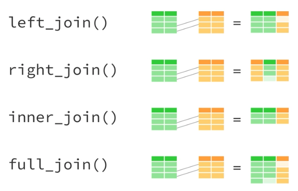

Unión de bases de datos usando diferentes tipos de `_join`. Fuente: William Surles (https://rpubs.com/williamsurles/293454)

Para unir los nombres de las entidades o de los municipios podríamos hacer un `case_when` gigante pero eso es poco eficiente dado que el INEGI nos provee de una base de datos (`decateml.csv`). Leámosla

```r
codigos_entidad <- read_csv("decateml.csv",
                            locale = locale(encoding = "WINDOWS-1252"))
```

Nota que las entidades son todas aquellas que en `cve_mun` y `cve_loc` tienen ceros. Primero hagamos una base de entidades quedándonos sólo con `cve_ent` y `nom_loc`:

```r
base_entidades <- codigos_entidad %>%
  filter(`cve_loc` == "0000") %>%
  filter(`cve_mun` == "000") %>%
  select(`cve_ent`, `nom_loc`) %>%
  rename(`Entidad federativa` = `nom_loc`)
```

```
# A tibble: 37 × 2
   cve_ent `Entidad federativa`
   <chr>   <chr>
 1 01      Aguascalientes
 2 02      Baja California
 3 03      Baja California Sur
 4 04      Campeche
 5 05      Coahuila de Zaragoza
 6 06      Colima
 7 07      Chiapas
 8 08      Chihuahua
 9 09      Ciudad de México
10 10      Durango
# … with 27 more rows
```

Nota que en la `base_entidades` la columna con la clave de la entidad se llama `cve_ent` mientras que en la base de `mortalidad_2017` se llama `Entidad`. Para juntar las bases usaremos un `left_join`. Esta instrucción lo que hace es tomar una base `grande` y pegarle el diccionario de datos de una base `pequeña` como sigue:

```r
grande %>% left_join(pequeña)
```

En nuestro caso la base grande es `mortalidad_2017` y la base pequeña es `base_entidades` y las variables en común son: `Entidad = cve_ent`.

```r
mortalidad_2017 <- mortalidad_2017 %>%
  left_join(base_entidades, by = c("Entidad" = "cve_ent"))
```

En el caso del municipio requerimos dos columnas `cve_ent` (`Entidad`) y `cve_mun` (`Municipio`). Para ello filtramos la base inicial del `INEGI`:

```r
base_municipios <- codigos_entidad %>%
  filter(`cve_loc` == "0000") %>%
  filter(`cve_mun` != "000") %>%
  select(`cve_ent`, `cve_mun`, `nom_loc`) %>%
  rename(`Nombre del municipio` = `nom_loc`)
```

y pegamos a nuestros datos:

```r
mortalidad_2017 <- mortalidad_2017 %>%
  left_join(base_municipios,
            by = c("Entidad" = "cve_ent",
                   "Municipio" = "cve_mun"))
```

Podemos entonces mostrar las defunciones para los municipios de `Sinaloa`:

```r
mortalidad_2017 %>%
  filter(`Entidad federativa` == "Sinaloa") %>%
  group_by(`Nombre del municipio`) %>%
  tally()
```

```
# A tibble: 18 × 2
   `Nombre del municipio`     n
   <chr>                  <int>
 1 Ahome                   2509
 2 Angostura                434
 3 Badiraguato              105
 4 Choix                    128
 5 Concordia                149
 6 Cosalá                    63
 7 Culiacán                5007
 8 El Fuerte                332
 9 Elota                    130
10 Escuinapa                292
11 Guasave                 1407
12 Mazatlán                2943
13 Mocorito                 214
14 Navolato                 549
15 Rosario                  249
16 Salvador Alvarado        354
17 San Ignacio               95
18 Sinaloa                  322
```

### 6.8 Pivoteo de bases con `pivot`

La siguiente tabla muestra por sexo y entidad las defunciones. Muchas veces para mejorar el formato buscamos transponer la tabla de tal forma que hombres sea una columna y mujeres otra. Éste no es el formato recomendado para análisis pero a veces sí para presentar. Para poder transformar la tabla podemos `pivot_wider`:

```r
#Tabla en formato largo (long)
formato_largo <- mortalidad_2017 %>%
  group_by(`Entidad federativa`, Sexo) %>%
  tally()
```

```r
formato_largo
```

```
# A tibble: 96 × 3
# Groups:   Entidad federativa [32]
   `Entidad federativa` Sexo       n
   <chr>                <chr>  <int>
 1 Aguascalientes       Hombre  3315
 2 Aguascalientes       Mujer   2669
 3 Aguascalientes       <NA>       2
 4 Baja California      Hombre 13135
 5 Baja California      Mujer   7420
 6 Baja California      <NA>      17
 7 Baja California Sur  Hombre  2617
 8 Baja California Sur  Mujer   1327
 9 Baja California Sur  <NA>       5
10 Campeche             Hombre  2526
# … with 86 more rows
```

Podemos decirle a `R` que vuelva cada sexo una columna. Para ello hay que especificar las variables que quedan constantes como columnas en `id_cols` (en este caso `Entidad federativa`) y las que van a cambiar a columna (`names_from`) `Sexo` junto con el valor asignar (`values_from`) `n`:

```r
formato_ancho <- formato_largo %>%
  pivot_wider(id_cols = `Entidad federativa`,
              names_from  = `Sexo`,
              values_from = `n`)
```

```
# A tibble: 32 × 4
# Groups:   Entidad federativa [32]
   `Entidad federativa` Hombre Mujer  `NA`
   <chr>                 <int> <int> <int>
 1 Aguascalientes         3315  2669     2
 2 Baja California       13135  7420    17
 3 Baja California Sur    2617  1327     5
 4 Campeche               2526  1945     6
 5 Chiapas               14474 12051     5
 6 Chihuahua             13845  9613    10
 7 Ciudad de México      39204 36096    10
 8 Coahuila de Zaragoza   8877  7256     4
 9 Colima                 3049  1820     2
10 Durango                4862  3627     1
# … with 22 more rows
```

por otro lado si tenemos una base en formato ancho `wide` y que queremos pasar a largo para su análisis (`long`) podemos trabajar con `pivot_longer` seleccionando en `cols` las columnas a transformar, bajo qué nombre quedan en `names_to` y bajo qué valor en `values_to`:

```r
#Y de regreso
formato_ancho %>%
  pivot_longer(cols = c(`Mujer`, `Hombre`, `NA`),
               names_to = "Sexo",
               values_to = "n")
```

```
# A tibble: 96 × 3
# Groups:   Entidad federativa [32]
   `Entidad federativa` Sexo       n
   <chr>                <chr>  <int>
 1 Aguascalientes       Mujer   2669
 2 Aguascalientes       Hombre  3315
 3 Aguascalientes       NA         2
 4 Baja California      Mujer   7420
 5 Baja California      Hombre 13135
 6 Baja California      NA        17
 7 Baja California Sur  Mujer   1327
 8 Baja California Sur  Hombre  2617
 9 Baja California Sur  NA         5
10 Campeche             Mujer   1945
# … with 86 more rows
```

### 6.9 Unión de columnas con `paste`

En nuestra base de datos tenemos el día, mes y año separados en las columnas homónimas. Podemos juntarlas en una sola con `paste` especificando cómo separarlas con `sep`:

```r
mortalidad_2017 <- mortalidad_2017 %>%
  mutate(Fecha = paste(Día, Mes, Año, sep = "-"))
```

```
# A tibble: 688,468 × 11
   Entidad Municipio Sexo    Edad   Día   Mes   Año Causa Entida…¹ Nombr…² Fecha
   <chr>   <chr>     <chr>  <dbl> <dbl> <dbl> <dbl> <chr> <chr>    <chr>   <chr>
 1 01      001       Mujer   4061     7     1  2017 C259  Aguasca… Aguasc… 7-1-…
 2 01      001       Hombre  4069    18     1  2017 K631  Aguasca… Aguasc… 18-1…
 3 01      001       Hombre  4091    20     1  2017 J441  Aguasca… Aguasc… 20-1…
 4 01      001       Mujer   4076     1     1  2017 I698  Aguasca… Aguasc… 1-1-…
 5 01      001       Hombre  4070    20     1  2017 C61X  Aguasca… Aguasc… 20-1…
 6 01      001       Mujer   4048    20     1  2017 K803  Aguasca… Aguasc… 20-1…
 7 01      001       Hombre  4062    12     1  2017 C61X  Aguasca… Aguasc… 12-1…
 8 01      001       Hombre  4089    13     1  2017 N390  Aguasca… Aguasc… 13-1…
 9 01      001       Mujer   4042     8     1  2017 E117  Aguasca… Aguasc… 8-1-…
10 01      001       Mujer   4085    14     1  2017 I120  Aguasca… Aguasc… 14-1…
# … with 688,458 more rows, and abbreviated variable names
#   ¹`Entidad federativa`, ²`Nombre del municipio`
```

Una vez que están unidas podemos usar la librería `lubridate` para convertirlas a fecha usando `dmy` si es día-mes-año o `ymd` si es año mes día (`mdy` ¿para qué será?)

```r
library(lubridate)
mortalidad_2017 <- mortalidad_2017 %>%
  mutate(Fecha = dmy(Fecha))
```

Una vez es convertida en fecha podemos hacer operaciones con fechas por ejemplo contar cuántos días han pasado desde el `01` de enero del `2017` hasta la fecha:

```r
mortalidad_2017 <- mortalidad_2017 %>%
  mutate(`Días desde primero de enero` = Fecha - dmy("01/01/2017"))
```

o bien obtener la semana epidemiológica y el año epidemiológico:

```r
mortalidad_2017 <- mortalidad_2017 %>%
  mutate(`Semana epidemiológica` = epiweek(Fecha)) %>%
  mutate(`Año epidemiológico` = epiyear(Fecha))
```

### 6.10 Ejercicio

> El ejercicio consiste en usar las siguientes funciones en una base de datos de tu preferencia al menos una vez para responder preguntas de la base de datos. + `filter` + `group_by` + `mutate` + `select` + `tally` + `rename` + `summarise` + Al menos una de las siguientes: `left_join`, `right_join`, `full_join`, `inner_join` + Al menos una de las siguientes: `pivot_longer`, `pivot_wider` + Una gráfica con `ggplot` Si no tienes una base de datos puedes usar la que sigue:

En el siguiente [hipervínculo](https://www.gob.mx/salud/documentos/datos-abiertos-152127) puedes encontrar la base de datos de **Enfermedades Febriles Exantemáticas** más reciente de la Dirección General de Epidemiología (`Base de Datos`) así como el significado de cada uno de los códigos en `Diccionario de Datos`. Cada renglón de la base de datos representa un caso distinto de una de estas enfermedades.

Utiliza la base para responder las siguientes preguntas usando al menos una vez (en todo el ejercicio) las funciones:

- `filter`
- `group_by`
- `mutate`
- `select`
- `tally`
- `rename`
- `summarise`
- Al menos una de las siguientes: `left_join`, `right_join`, `full_join`, `inner_join`
- Al menos una de las siguientes: `pivot_longer`, `pivot_wider`
- Una gráfica con `ggplot`
1. ¿Cuántos casos se han presentado este año?
2. ¿Cuántos presentaron fiebre?
3. ¿Cuántos casos en hombres y cuántos en mujeres?
4. ¿Cuál es la edad promedio de los casos?
5. De los casos ¿cuántos hombres estaban vacunados y cuántas mujeres vacunadas?. Genera una tabla de 2 por 2 que se vea **exactamente** así:

   |  | Hombres | Mujeres |
   | --- | --- | --- |
   | Con al menos una vacuna | --- | --- |
   | Sin vacuna | --- | --- |

6. De los casos ¿qué proporción de los hombres estaban vacunados y qué proporción de las mujeres vacunadas?
7. Utiliza la población del [`Censo 2020` del INEGI](https://www.inegi.org.mx/programas/ccpv/2020/#Tabulados) para calcular la incidencia por cada 10000 habitantes por entidad y encontrar la entidad con mayor incidencia.
8. Grafica la incidencia de casos totales por semana epidemiológica usando `ggplot2`.

### 6.11 Para saber más

La mayor recomendación es el libro `R4DS` (`R` para ciencia de datos) el cual puede encontrarse gratuitamente en línea: **nueva edición (inglés)**: https://r4ds.had.co.nz/ **edición previa (español)**: https://es.r4ds.hadley.nz/